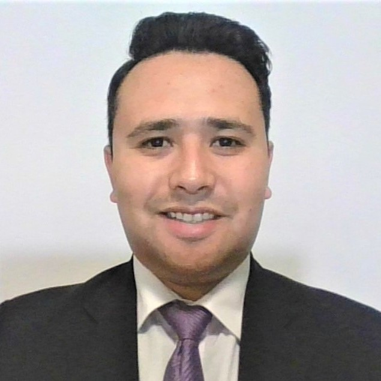

# J.Manuel Magana A

## Bio

Data Scientist with proven experience at the intersection of statistics, machine learning, econometrics, financial reporting and data visualization. A naturally curious, persistent, well-organized and self-motivated person who loves to learn and lead others to solve challenging problems with pragmatic solutions using leading edge technology. Enjoys working with international and multicultural teams.

Areas of Expertise:

• Statistics and machine learning (R, Python) • Econometrics (R, Python) • Data Visualisation (QlikView, Tableau, R Shiny) • Data handling and databases (SQL, MicroStrategy) • Data Science project management (Azure DevOps, GitHub)

## Education

**Birkbeck, University of London** | London, UK

MSc in Data Science | 2018 - 2020

**Monterrey Institute of Technology** | Queretaro, Mexico

MSc in Finance | 2010 - 2012

**Monterrey Institute of Technology** | Queretaro, Mexico

BSc Mechatronics Engineering | 2005 - 2010

## Publications

[Value Relevance of Accounting Fundamentals in the Mexican Stock Exchange](https://www.academia.edu/14449992/VALUE_RELEVANCE_OF_ACCOUNTING_FUNDAMENTALS_IN_THE_MEXICAN_STOCK_EXCHANGE) | 2012 | American Council of Management Schools (CLADEA).

## Experience

**PwC Spain** | Data Scientist, Manager | 2021 - Present

**PwC UK** | Data Scientist, Manager | 2017 - 2020

**PwC UK** | Data Analytics, Senior Associate | 2013 - 2017

**Monterrey Institute of Technology** | Lecturer (Part time) | 2013 - 2016

**PwC UK** | Business Analyst | 2011 - 2013

**Mars Inc** | Financial Analyst | 2010 - 2011